# Reproducible Research: Peer Assessment 2

## Top Storm and Weather Impacts on Health and Property

## USA, 1996-2011

### Synopsis

This report surveys the impacts of major storms and weather events in the United States from 1996 through 2011. Our goal was to identify the storm/weather types that were most harmful to human health, as well as those types that had the greatest economic consequences. To perform this analysis, we obtained a version of the U.S. National Oceanic and Atmospheric Administration’s (NOAA’s) storm database. We focused on the period from 1996 through 2011, when the data set was more reliable and complete. Analysis determined the top 10 event types for harm to human health. For example, the top 3 of these event types were tornadoes, heat, and floods. Analysis also determined the top 10 event types for damage to property and crops. For example, the top 3 of these event types were floods, hurricanes, and storm surges.

### Loading and processing the raw data

A version of the [U.S. National Oceanic and Atmospheric Administration’s](http://www.ncdc.noaa.gov/) storm database was obtained from the instructors of the [Reproducible Research](https://www.coursera.org/course/repdata) course on Coursera. The file was distributed as a BZ2 archive of a table in CSV format. NA’s are indicated by empty strings.

[Storm data documentation](https://d396qusza40orc.cloudfront.net/repdata%2Fpeer2_doc%2Fpd01016005curr.pdf) from the National Weather Service is available via the Coursera class. In addition, an [FAQ on storm events](https://d396qusza40orc.cloudfront.net/repdata%2Fpeer2_doc%2FNCDC%20Storm%20Events-FAQ%20Page.pdf) is available from the National Climatic Data Center.

#### Reading in the events data

The unzipped storm data file must be in the working directory for this script to run. If the file hasn’t already been downloaded, let’s download it, read it, save it to disk, and extract the column classes for future use. If the CSV file is already in the working directory, we read it (using a function from the readr library for speed).

```r
library(dplyr)
library(readr)

storm_zip_file <- "StormData.csv.bz2"
storm_csv_file <- "StormData.csv"

col_classes <- c("icccicccnccccicnccniciiincncccccicicn")
if (!file.exists(storm_zip_file)) {
    download.file("https://d396qusza40orc.cloudfront.net/repdata%2Fdata%2FStormData.csv.bz2",
                  storm_zip_file, method = "curl")
    storm_data <- read.csv(storm_zip_file, na = "")
    write_csv(storm_data, storm_csv_file)
    classes <- sapply(storm_data, class)
} else {
    storm_data <- read_csv(storm_csv_file, na = "", col_types = col_classes)
}
```

Let’s examine the size of the data table that we have just loaded.

```r
dimensions <- dim(storm_data)
```

The data set contains 902297 rows and 37 columns.

Let’s look at the first few rows of the data set, to get a sense of column names and typical values.

```r
head(storm_data, 5)
```

```
## Source: local data frame [5 x 37]
##
##   STATE__           BGN_DATE BGN_TIME TIME_ZONE COUNTY COUNTYNAME STATE
## 1       1  4/18/1950 0:00:00     0130       CST     97     MOBILE    AL
## 2       1  4/18/1950 0:00:00     0145       CST      3    BALDWIN    AL
## 3       1  2/20/1951 0:00:00     1600       CST     57    FAYETTE    AL
## 4       1   6/8/1951 0:00:00     0900       CST     89    MADISON    AL
## 5       1 11/15/1951 0:00:00     1500       CST     43    CULLMAN    AL
## Variables not shown: EVTYPE (chr), BGN_RANGE (dbl), BGN_AZI (chr),
##   BGN_LOCATI (chr), END_DATE (chr), END_TIME (chr), COUNTY_END (int),
##   COUNTYENDN (chr), END_RANGE (dbl), END_AZI (chr), END_LOCATI (chr),
##   LENGTH (dbl), WIDTH (int), F (chr), MAG (int), FATALITIES (int),
##   INJURIES (int), PROPDMG (dbl), PROPDMGEXP (chr), CROPDMG (dbl),
##   CROPDMGEXP (chr), WFO (chr), STATEOFFIC (chr), ZONENAMES (chr), LATITUDE
##   (chr), LONGITUDE (int), LATITUDE_E (chr), LONGITUDE_ (int), REMARKS
##   (chr), REFNUM (dbl)
```

Conveniently, the columns names are already legal for use with data frames in R.

Now, to enhance performance and reduce memory load, let’s extract only the columns that we’ll be using in this analysis.

```r
library(dplyr)
storm_data_trim <- select(storm_data, BGN_DATE, EVTYPE, FATALITIES, INJURIES, PROPDMG,
                          PROPDMGEXP, CROPDMG, CROPDMGEXP)
```

To increase the literacy of the code chunks in this R Markdown file, let’s make the column names more readable.

```r
names(storm_data_trim) <- c("Begin_Date", "Event_Type", "Fatalities", "Injuries",
                            "Property_Damage", "Property_Damage_Exp", "Crop_Damage",
                            "Crop_Damage_Exp")
```

Next, let’s get a summary of the storm impact variables that we’ll be using.

```r
summary(storm_data_trim$Fatalities)
```

```
##     Min.  1st Qu.   Median     Mean  3rd Qu.     Max.
##   0.0000   0.0000   0.0000   0.0168   0.0000 583.0000
```

```r
summary(storm_data_trim$Injuries)
```

```
##      Min.   1st Qu.    Median      Mean   3rd Qu.      Max.
##    0.0000    0.0000    0.0000    0.1557    0.0000 1700.0000
```

```r
summary(storm_data_trim$Property_Damage)
```

```
##    Min. 1st Qu.  Median    Mean 3rd Qu.    Max.
##    0.00    0.00    0.00   12.06    0.50 5000.00
```

```r
summary(storm_data_trim$Crop_Damage)
```

```
##    Min. 1st Qu.  Median    Mean 3rd Qu.    Max.
##   0.000   0.000   0.000   1.527   0.000 990.000
```

According to the [NOAA](http://www.ncdc.noaa.gov/stormevents/details.jsp) and the [IRE](https://ire.org/media/uploads/files/datalibrary/samplefiles/Storm%20Events/readme_08.doc), the data from 1996 onward are more reliable and complete than earlier data So let’s subset the data to only this period. Also, let’s record the range of years for use later in this analysis.

```r
library(lubridate)
first_year <- 1996
storm_data_dates <- storm_data_trim %>%
    mutate(Date_Time = mdy_hms(Begin_Date)) %>%
    mutate(Year = year(Date_Time)) %>%
    filter(Year >= first_year) %>%
    select(-Date_Time, -Begin_Date)
year_range <- max(storm_data_dates$Year) - first_year
```

Let’s see how many missing values are contained in the columns that we’ll be using. These values could potentially causes problems with the analysis.

```r
data.frame(Event_Type = sum(is.na(storm_data_dates$Event_Type)),
           Fatalities = sum(is.na(storm_data_dates$Fatalities)),
           Injuries = sum(is.na(storm_data_dates$Injuries)),
           Property_Damage = sum(is.na(storm_data_dates$Property_Damage)),
           Property_Damage_Exp = sum(is.na(storm_data_dates$Property_Damage_Exp)),
           Crop_Damage = sum(is.na(storm_data_dates$Crop_Damage)),
           Crop_Damage_Exp = sum(is.na(storm_data_dates$Crop_Damage_Exp)))
```

```
##   Event_Type Fatalities Injuries Property_Damage Property_Damage_Exp
## 1          0          0        0               0                   0
##   Crop_Damage Crop_Damage_Exp
## 1           0               0
```

Fortunately there are no missing values in these columns.

Given the frequency of zero values in this data set, and our goal of focusing on high-impact storms and weather events, let’s filter out observations that have no impacts for human health or property/crop damage.

```r
storm_data_damage <- storm_data_dates %>%
    filter(Injuries > 0 | Fatalities > 0 | Property_Damage > 0 | Crop_Damage > 0)
```

#### Adjusting damage costs

In the data set, property and crop damage are recorded in two columns as dollar figures and base-10 exponents. We need to reconstruct the original figures by multiplication. Let’s make the following assumptions in interpreting the exponent columns: upper and lower case versions of an alphabetic character have the same meaning, and digits signify base-10 exponentiation.

```r
exp_function <- function(exp_letter) {
    return(ifelse(exp_letter == "B", 1000000000,
                  ifelse(exp_letter == "M" | exp_letter == 'm', 1000000,
                         ifelse(exp_letter == "K", 1000,
                                ifelse(exp_letter == "H" | exp_letter == 'h', 100,
                                       ifelse(is.finite(exp_letter),
                                              10 ^ as.numeric(exp_letter),
                                              1))))))
}
storm_data_exp <- storm_data_damage %>%
    mutate(Property_Damage = Property_Damage * exp_function(Property_Damage_Exp)) %>%
    mutate(Crop_Damage = Crop_Damage * exp_function(Crop_Damage_Exp)) %>%
    select(-Property_Damage_Exp, -Crop_Damage_Exp)
```

Given the length of the analysis period, it’s best to adjust costs for inflation. The data come from the [U.S. Bureau of Labor Statistics](http://www.bls.gov/), via the [economic research unit of the Federal Reserve Bank of St. Louis](https://research.stlouisfed.org). The data can be downloaded interactively from the following URL: https://research.stlouisfed.org/fred2/series/CPIAUCSL/downloaddata . On this page, we make the following choices: “Index 1982-84=100”, Annual, Average, 1947-01-01 to 2015-04-01, and Excel. Then we click the Download Data button, and save the file in our current working directory.

```r
library(xlsx)

cpi_data <- read.xlsx("CPIAUCSL.xls", sheetIndex = 1, startRow = 55, endRow = 123) %>%
    rename(Date = DATE, Value = VALUE) %>%
    mutate(Date = ymd(Date)) %>%
    mutate(Year = year(Date)) %>%
    select(-Date)
value_2014 <- filter(cpi_data, Year == 2014) %>% select(Value)

storm_data_inflated <- storm_data_exp %>%
    inner_join(cpi_data, by = "Year") %>%
    mutate(Property_Damage = (Property_Damage * (value_2014$Value/Value))) %>%
    mutate(Crop_Damage = Crop_Damage * (value_2014$Value/Value)) %>%
    select(-Year)
```

#### Cleaning up the event-type variable

How many unique event types are listed in the data set?

```r
num_event_types <- length(unique(storm_data_inflated$Event_Type))
```

It turns out that there’s a large number: 222. We should clean up this list before proceeding with the analysis, in order to ensure that the most significant storm/weather types are identified. Cleaning up more minor event types fully is not required at this time, for an exploratory data analysis. However, future analysis would benefit from cleanup of all event types in the database (for which a SME and significant time are probably required).

First, let’s perform some general lexical clean-up.

```r
storm_data_clean_1 <- storm_data_inflated %>%
    filter(!grepl("summary", Event_Type, ignore.case = TRUE)) %>%
    mutate(Event_Type = tolower(Event_Type)) %>%
    mutate(Event_Type = gsub("^[[:space:]]*", "", Event_Type)) %>%
    mutate(Event_Type = gsub("  [[:space:]]*", " ", Event_Type)) %>%
    mutate(Event_Type = gsub("[[:space:]]?mph$", "", Event_Type)) %>%
    mutate(Event_Type = gsub(" f[[:digit:]]$", "", Event_Type)) %>%
    mutate(Event_Type = gsub(" [[:punct:]]*g[[:digit:]]*[[:punct:]]*$",
                             "", Event_Type)) %>%
    mutate(Event_Type = gsub(" ([[:digit:]]|[[:punct:]])*$", "", Event_Type)) %>%
    mutate(Event_Type = gsub(" advisory| advisories| damage", "", Event_Type)) %>%
    mutate(Event_Type = gsub("&", "and", Event_Type)) %>%
    mutate(Event_Type = gsub("and$", "", Event_Type))
```

Second, let’s correct obvious misspellings and word variations.

```r
storm_data_clean_2 <- storm_data_clean_1 %>%
    mutate(Event_Type = gsub("cstl", "coastal", Event_Type)) %>%
    mutate(Event_Type = gsub("devel", "devil", Event_Type)) %>%
    mutate(Event_Type = gsub("hvy", "heavy", Event_Type)) %>%
    mutate(Event_Type = gsub("clou$", "cloud", Event_Type)) %>%
    mutate(Event_Type = gsub("cool", "cold", Event_Type)) %>%
    mutate(Event_Type = gsub("flooding|floods", "flood", Event_Type)) %>%
    mutate(Event_Type = gsub("flood flash|flash flood from ice jams",
                             "flash flood", Event_Type)) %>%
    mutate(Event_Type = gsub("flash flood.?$|flashflood",
                             "flash flood", Event_Type)) %>%
    mutate(Event_Type = gsub("heat waves", "heat wave", Event_Type)) %>%
    mutate(Event_Type = gsub("/ street", "", Event_Type)) %>%
    mutate(Event_Type = gsub("storms", "storm", Event_Type)) %>%
    mutate(Event_Type = gsub("storm surge/tide", "storm surge", Event_Type)) %>%
    mutate(Event_Type = gsub("torndao", "tornado", Event_Type)) %>%
    mutate(Event_Type = gsub("[/]? tree[s]?", "", Event_Type)) %>%
    mutate(Event_Type = gsub("vog", "fog", Event_Type)) %>%
    mutate(Event_Type = gsub("windchill", "wind chill", Event_Type)) %>%
    mutate(Event_Type = gsub("tstm|thun[[:alpha:]]*", "t-storm", Event_Type))
```

Third, let’s combine some synonyms that don’t seem to require subject-matter expertise for interpretation. This includes generalizing each named storm to its category, in order to support better grouping for the exploratory analysis.

```r
storm_data_clean_3 <- storm_data_clean_2 %>%
    mutate(Event_Type = gsub("dry|very dry|abnormally dry", "drought", Event_Type)) %>%
    mutate(Event_Type = gsub("hot weather|hot spell|hot pattern", "heat",
                             Event_Type)) %>%
    mutate(Event_Type = gsub("abnormal warmth|extreme heat|unusually warm",
                         "excessive heat", Event_Type)) %>%
    mutate(Event_Type = gsub("unseasonably warm|unseasonably hot|unusual warmth",
                         "excessive heat", Event_Type)) %>%
      mutate(Event_Type = gsub("very warm|record heat|record/excessive heat",
                         "excessive heat", Event_Type)) %>%
    mutate(Event_Type = gsub("low temperature", "cold", Event_Type)) %>%
    mutate(Event_Type = gsub(" temperature", "", Event_Type)) %>%
    mutate(Event_Type = gsub("bitter cold|unusually cold|unseasonably cold",
                         "extreme cold", Event_Type)) %>%
    mutate(Event_Type = gsub("unseasonable cold|severe cold|hypothermia.*",
                         "extreme cold", Event_Type)) %>%
    mutate(Event_Type = gsub("^fog$", "dense fog", Event_Type)) %>%
    mutate(Event_Type = gsub("agricultural freeze|damaging freeze",
                             "frost/freeze", Event_Type)) %>%
    mutate(Event_Type = gsub("^freeze$|hard freeze", "frost/freeze", Event_Type)) %>%
    mutate(Event_Type = gsub("early frost|^frost$", "frost/freeze", Event_Type)) %>%
    mutate(Event_Type = gsub("heavy surf|hazardous surf|heavy surf/high surf",
                              "high surf", Event_Type)) %>%
    mutate(Event_Type = gsub("rough surf|rough wave|rough seas",
                             "high surf", Event_Type)) %>%
    mutate(Event_Type = gsub("hurricane/typhoon|hurricane [[:alpha:]]*",
                             "hurricane", Event_Type)) %>%
    mutate(Event_Type = gsub("debris flow|landslides|landslump|mud slide[s]?",
                         "landslide", Event_Type)) %>%
    mutate(Event_Type = gsub("lightning injury", "lightning", Event_Type)) %>%
    mutate(Event_Type = gsub("rip currents", "rip current", Event_Type)) %>%
    mutate(Event_Type = gsub("urban.*", "urban flood", Event_Type)) %>%
    mutate(Event_Type = gsub("tornados|tornadoes", "tornado", Event_Type)) %>%
    mutate(Event_Type = gsub("tropical storm.*", "tropical storm", Event_Type)) %>%
    mutate(Event_Type = gsub("volcanic.*", "volcanic ash", Event_Type)) %>%
    mutate(Event_Type = gsub("water spout|waterspout funnel cloud|waterspout-$",
                         "waterspout", Event_Type)) %>%
    mutate(Event_Type = gsub("waterspouts|wayterspout|waterspout/",
                         "waterspout", Event_Type)) %>%
    mutate(Event_Type = gsub("wild/forest", "wild", Event_Type)) %>%
    mutate(Event_Type = gsub("wild fire|wildfires|brush fire[s]?", "wildfire",
                             Event_Type)) %>%
    mutate(Event_Type = gsub("wnd|winds|wins|non[ |-]thunderstorm wind", "wind",
                             Event_Type)) %>%
    mutate(Event_Type = gsub("high wind.?$|^wind$", "high wind", Event_Type)) %>%
    mutate(Event_Type = gsub("wintery|wintry", "winter", Event_Type)) %>%
    mutate(Event_Type = gsub("winter weather[ |/]mix", "winter mix", Event_Type))
```

Finally, on a discretionary basis, let’s combine high-impact event types that are closely related, again, for exploratory purposes. Such event types reflect only  
differences of degree, rather than of kind. Any findings that we obtain in this analysis can be investigated more closely in the future, potentially.

```r
storm_data_clean_4 <- storm_data_clean_3 %>%
    mutate(Event_Type = gsub("heat wave", "heat", Event_Type)) %>%
    mutate(Event_Type = gsub("excessive heat", "heat", Event_Type)) %>%
    mutate(Event_Type = gsub("extreme cold", "cold", Event_Type)) %>%
    mutate(Event_Type = gsub("cold/wind chill", "cold", Event_Type)) %>%
    mutate(Event_Type = gsub("strong wind", "high wind", Event_Type)) %>%
    mutate(Event_Type = gsub("avalanche", "landslide", Event_Type)) %>%
    arrange(Event_Type)
```

### Results

#### Overview of processed data

Now that the data have been cleaned up, let’s get a graphical overview through a set of box plots. As usual, we’ll focus on the storm impact variables. The ggplot2 library was chosen for plotting throughout this analysis, because of the library’s unified conceptual model, its rich set of primitives, and its attractive and clear output. A log scale is used for the boxplots, given the data’s wide range and the frequency of near-zero values.

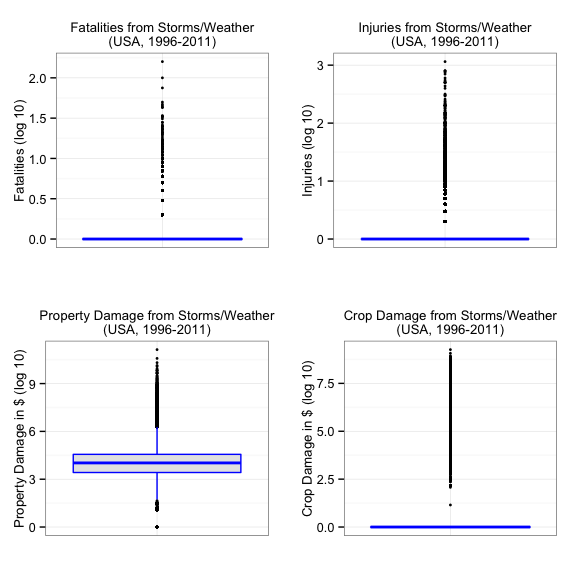

```r
library(ggplot2)
library(gridExtra)

g <- ggplot(storm_data_clean_4, aes(x = factor(0), y = log10(Fatalities + 1)))
plot_1 <- g + geom_boxplot(col = "blue", fill = "gray90", outlier.size = 1) +
    xlab("") + ylab("Fatalities (log 10)") + theme_bw() +
    theme(axis.text.x = element_blank(), axis.ticks.x = element_blank()) +
    ggtitle("Fatalities from Storms/Weather\n(USA, 1996-2011)") +
    theme(axis.title.y = element_text(size = 10)) +
    theme(plot.title = element_text(size = 10, vjust = 0.75))

g <- ggplot(storm_data_clean_4, aes(x = factor(0), y = log10(Injuries + 1)))
plot_2 <- g + geom_boxplot(col = "blue", fill = "gray90", outlier.size = 1) +
    xlab("") + ylab("Injuries (log 10)") + theme_bw() +
    theme(axis.text.x = element_blank(), axis.ticks.x = element_blank()) +
    ggtitle("Injuries from Storms/Weather\n(USA, 1996-2011)") +
    theme(axis.title.y = element_text(size = 10)) +
    theme(plot.title = element_text(size = 10, vjust = 0.75))

g <- ggplot(storm_data_clean_4, aes(x = factor(0), y = log10(Property_Damage + 1)))
plot_3 <- g + geom_boxplot(col = "blue", fill = "gray90", outlier.size = 1) +
    xlab("") + ylab("Property Damage in $ (log 10)") + theme_bw() +
    theme(axis.text.x = element_blank(), axis.ticks.x = element_blank()) +
    ggtitle("Property Damage from Storms/Weather\n(USA, 1996-2011)") +
    theme(axis.title.y = element_text(size = 10)) +
    theme(plot.title = element_text(size = 10, vjust = 0.75))

g <- ggplot(storm_data_clean_4, aes(x = factor(0), y = log10(Crop_Damage + 1)))
plot_4 <- g + geom_boxplot(col = "blue", fill = "gray90", outlier.size = 1) +
    xlab("") + ylab("Crop Damage in $ (log 10)") + theme_bw() +
    theme(axis.text.x = element_blank(), axis.ticks.x = element_blank()) +
    ggtitle("Crop Damage from Storms/Weather\n(USA, 1996-2011)") +
    theme(axis.title.y = element_text(size = 10)) +
    theme(plot.title = element_text(size = 10, vjust = 0.75))

grid.arrange(plot_1, plot_2, plot_3, plot_4, ncol=2)
```

The boxplots for fatalities, injuries, and crop damage show that only outliers depart significantly from the zero range. However, the impact of these outliers is significant in real-world terms, so the outliers are retained in the analysis.

The boxplot for property damage shows that most damage falls in the range between $1000 and $100,000. Significant outliers are present, as with the other impact variables.

#### Visualizing events with the greatest impact

To conclude this report and to answer the questions motivating the analysis, let’s vizualize the impact of the most significant storm and weather events. These impacts are in human terms (fatalities, injuries) and in economic terms (property and crop damage). Stacked bar charts show three results: * Which storm and weather events have the most impact? (Let’s use the top 10 as a conventional threshold.) * How do these top events rank relative to each other? * How do impact subtypes (e.g., crop damage) contribute to each major event?

First, let’s look at harm to human populations, in terms of fatalities and injuries. Storm and weather impacts are shown as annual averages, in order to give a sense of norms for planning purposes.

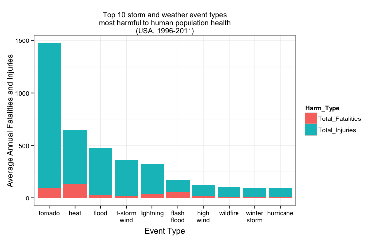

```r
library(tidyr)
storm_data_plot <- mutate(storm_data_clean_4, Event_Type = gsub("[ /]", "\n", Event_Type))

storm_data_harm <- storm_data_plot %>%
    group_by(Event_Type) %>%
    summarize(Total_Fatalities = sum(Fatalities),
              Total_Injuries = sum(Injuries),
              Total_Harm = Total_Fatalities + Total_Injuries) %>%
    arrange(desc(Total_Harm))
storm_data_harm_high <- storm_data_harm %>%
  top_n(10, Total_Harm) %>%
  gather("Harm_Type", "Number_People", 2:3) %>%
  mutate(Event_Type = reorder(Event_Type, -Total_Harm))

g <- ggplot(storm_data_harm_high,
            aes(Event_Type, Number_People / year_range, fill = Harm_Type))
p <- g + geom_bar(stat = "identity") +
    xlab("Event Type") + ylab("Average Annual Fatalities and Injuries") +
    ggtitle("Top 10 storm and weather event types\nmost harmful to human population health\n(USA, 1996-2011)") + theme_bw() +
    theme(axis.title.x = element_text(vjust=-0.25)) +
    theme(plot.title = element_text(size = 11))
print(p)
```

The plot shows that the top 10 events for human harm are, in descending order of impact: tornados, heat, floods, thunderstorm winds, lightning, flash floods, high wind, wildfires, winter storms, and hurricanes. Tornadoes stand out as having approximately double the impact of any other major event. In general, the number of fatalities is much lower than the number of injuries for a given event.

Second, let’s look at damage to property and crops.

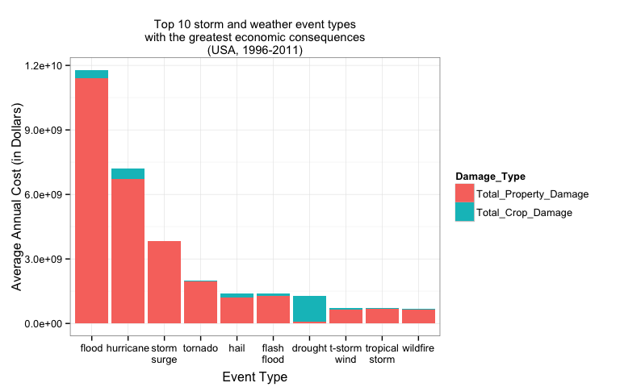

```r
storm_data_damage <- storm_data_plot %>%
    group_by(Event_Type) %>%
    summarize(Total_Property_Damage = sum(Property_Damage),
              Total_Crop_Damage = sum(Crop_Damage),
              Total_Damage = Total_Property_Damage + Total_Crop_Damage) %>%
    arrange(desc(Total_Damage))
storm_data_damage_high <- storm_data_damage %>%
  top_n(10, Total_Damage) %>%
  gather("Damage_Type", "Cost", 2:3) %>%
  mutate(Event_Type = reorder(Event_Type, -Total_Damage))

g <- ggplot(storm_data_damage_high, aes(Event_Type, Cost / year_range, fill = Damage_Type))
p <- g + geom_bar(stat = "identity") +
    xlab("Event Type") + ylab("Average Annual Cost (in Dollars)") +
    ggtitle("Top 10 storm and weather event types\nwith the greatest economic consequences\n(USA, 1996-2011)") + theme_bw() +
    theme(axis.title.x = element_text(vjust=-0.25)) +
    theme(plot.title = element_text(size = 11))
print(p)
```

The plot shows that the top 10 events for causing economic damage are, in descending order of impact: fllods, hurricanes, storm surges, tornadoes, hail, flash floods, drought, thunderstorm winds, tropical storms, and wildfires.

Comparing these two bar graphs, the difference in event ranking is striking. While six of the event types are shared between the graphs, the worst economic damage comes from floods, and the worst human harm comes from tornadoes. Only floods are among the top three events in each plot Hurricanes are shown as the second most costly storm, but the tenth most harmful storm for human health. Relative to other top economic impacts, drought has a significantly higher contribution from crop damage.

Finally, it’s worth noting the obvious: storm and weather events have major impact on property, crops, and human health. This is a significant area for research and planning.